# Reddit Survey Assignment

Nayan Saikia

March 9, 2016

Assignment is to predict income level based on features provided in the dataset. 1. Aggregate all countries to continent: At first I was not sure why this needs to be done as country would probably predict income level better than continent. But quickly found out that random forest cannot process that many levels and it also cannot process character data (atleast not in this instance). So, to aggregate countries to continent, I created a separate csv list and read that into my program. The list had some extra columns that I dropped

```r
reddit <- read.csv('/home/awaz/Documents/UISCourses/DataScience/RedditShortDemoSurvey-1-Cleaned.csv')
#create a column with continent name
coc <- read.csv('/home/awaz/Documents/UISCourses/DataScience/Countries-Continents-csv.csv',stringsAsFactors = FALSE)
coc <- coc[which(names(coc) %in% c("Continent", "Country"))]
```

Next, I sorted the reddit list and my continent list by country. This is an attempt to keep Big-O of my code piece mostly linear (afterall the reddit dataset has about 35k records). I ran this code piece multiple times and reviewed the results, based on which I cleaned up the country data. I eventually did drop about 800 records that did not have any country specified, but best cause would have been to create a label for those. a) Convert country from factor to string/character b) Remove any trailing or leading spaces when I am comparing the data c) Convert to lower case when comparing d) Remove any accented names (lots of ‘Mexico’ with an accented ‘e’)

```r
coc <- coc[which(names(coc) %in% c("Continent", "Country"))]
reddit$Treated.country.data <- as.character(reddit$Treated.country.data)
reddit$Treated.country.data[reddit$Treated.country.data == "Amerikka"] <- "United States"
reddit$Treated.country.data[reddit$Treated.country.data == "Amurika"] <- "United States"
reddit$Treated.country.data[grep("Canada",reddit$Treated.country.data,value = FALSE,fixed = TRUE)] <- "Canada"
reddit$Treated.country.data[grep("Austra",reddit$Treated.country.data,value = FALSE,fixed = TRUE)] <- "Australia"
reddit$Treated.country.data[grep("England",reddit$Treated.country.data,value = FALSE,fixed = TRUE)] <- "England"
reddit$Treated.country.data[reddit$Treated.country.data == "Bosnia and Herzegowina"] <- "Bosnia and Herzegovina"
reddit$Treated.country.data <- iconv(reddit$Treated.country.data,from = "UTF-8",to = "ASCII//TRANSLIT")
reddit.sorted <- reddit[order(reddit$Treated.country.data),]
coc.sorted <- coc[order(coc$Country),]
```

Following is my code to assign country to continent:

```r
j <- 1
for (i in 1:nrow(reddit.sorted)) {
  if(tolower(trimws(reddit.sorted$Treated.country.data[i])) == tolower(trimws(coc.sorted$Country[j])))
  {
    reddit.sorted$continent[i] <- coc.sorted$Continent[j]
  }
  else
  {
    saved.j <- j
    j <- j + 1
    while (j <= nrow(coc.sorted)) {
      if(tolower(trimws(reddit.sorted$Treated.country.data[i])) == tolower(trimws(coc.sorted$Country[j]))){
        reddit.sorted$continent[i] <- coc.sorted$Continent[j]
        break
      }
      j <- j + 1
    }
    if(j > nrow(coc.sorted)){
      j <- saved.j
      reddit.sorted$continent[i] <- "unknown"
    }
  }
}
```

I explored the results as shown below and went back to make changes (execution turned off):

```r
#extract out only "unknown" continents. Lots of unknown, lots of cleaup
reddit.explore <- reddit.sorted[reddit.sorted$continent == "unknown",]
reddit.explore <- reddit.explore[,which(names(reddit.explore) %in% c("Treated.country.data", "continent"))]
View(reddit.explore)
```

```r
#countries are cleaned up as best as possible, dropping the unknown rows
reddit.sorted.cln1 <- reddit.sorted[reddit.sorted$continent != "unknown",]
#treated.subreddit.data seems to be garbage - deleting this for now. Also drop the question on US state
#Not sure if the 'X' variables offer much. So will remove these as well
#Dropping entry.id as well
reddit.sorted.cln1 <- reddit.sorted.cln1[-which(names(reddit.sorted.cln1) %in% c("Entry.Id","treated.subreddit.data",
                "X.For.U..S..redditors..In.which.state.do.you.live.", "X", "X.1", "X.2", "X.3", "X.4", "X.5"))]
str(reddit.sorted.cln1)
```

```
## 'data.frame':    31941 obs. of  12 variables:
##  $ Please.indicate.your.gender.                                                               : Factor w/ 3 levels "Female","Male",..: 2 2 2 2 1 2 2 2 1 2 ...
##  $ Please.select.the.category.that.includes.your.age.                                         : Factor w/ 8 levels "18-24","25-34",..: 1 2 2 1 1 1 8 2 1 2 ...
##  $ What.is.your.marital.status.                                                               : Factor w/ 7 levels "Blank","Engaged",..: 6 3 6 4 4 6 6 6 4 3 ...
##  $ What.best.describes.your.employment.status.                                                : Factor w/ 7 levels "Employed full time",..: 1 1 1 1 7 7 7 5 7 1 ...
##  $ Are.you.or.have.you.ever.been.in.military.service.                                         : Factor w/ 3 levels "No","none","Yes": 1 1 3 1 1 1 1 1 1 1 ...
##  $ Do.you.currently.have.children.under.the.age.of.18.living.in.your.household.               : Factor w/ 3 levels "No","None","Yes": 1 1 1 1 3 1 1 1 1 1 ...
##  $ What.best.describes.your.level.of.education.                                               : Factor w/ 8 levels "Associate degree",..: 2 3 6 1 6 3 4 4 6 2 ...
##  $ Treated.country.data                                                                       : chr  "Afghanistan" "Afghanistan" "Afghanistan" "Albania" ...
##  $ Which.one.of.the.following.ranges.includes.your.total.yearly.household.income.before.taxes.: Factor w/ 9 levels "$100,000 - $149,999",..: 3 9 2 9 4 9 9 8 9 2 ...
##  $ Are.you.a.dog.or.a.cat.person.                                                             : Factor w/ 8 levels "","askreddit",..: 3 5 5 4 3 4 3 4 5 3 ...
##  $ If.you.were.a.cheese..what.cheese.would.you.be.                                            : Factor w/ 17 levels "1","American",..: 13 5 16 5 7 12 5 10 4 16 ...
##  $ continent                                                                                  : chr  "Asia" "Asia" "Asia" "Europe" ...
```

```r
#Lets check levels of each variable
levels(reddit.sorted.cln1$What.best.describes.your.employment.status.)
```

```
## [1] "Employed full time"
## [2] "Freelance"
## [3] "None"
## [4] "Not employed and not looking for work"
## [5] "Not employed, but looking for work"
## [6] "Retired"
## [7] "Student"
```

```r
levels(reddit.sorted.cln1$Are.you.a.dog.or.a.cat.person.)
```

```
## [1] ""                "askreddit"       "I like cats."    "I like dogs."
## [5] "I like turtles." "movies"          "none"            " Reddit.com"
```

```r
#It looks like 'movies', 'askreddit' and 'Reddit.com' values are removed from the dataframe. So, refactoring
#to drop these variables. Looks like ' reddit.com' and '' still exists. So dropping these
reddit.sorted.cln1 <- reddit.sorted.cln1[reddit.sorted.cln1$Are.you.a.dog.or.a.cat.person.!= " Reddit.com" &
                                         reddit.sorted.cln1$Are.you.a.dog.or.a.cat.person. != "",]
reddit.sorted.cln1$Are.you.a.dog.or.a.cat.person. <- factor(reddit.sorted.cln1$Are.you.a.dog.or.a.cat.person.)
levels(reddit.sorted.cln1$Are.you.a.dog.or.a.cat.person.)
```

```
## [1] "askreddit"       "I like cats."    "I like dogs."    "I like turtles."
## [5] "movies"          "none"
```

```r
#Lets check all other levels
levels(reddit.sorted.cln1$Which.one.of.the.following.ranges.includes.your.total.yearly.household.income.before.taxes.)
```

```
## [1] "$100,000 - $149,999" "$150,000 or more"    "$20,000 - $29,999"
## [4] "$30,000 - $39,999"   "$40,000 - $49,999"   "$50,000 - $69,999"
## [7] "$70,000 - $99,999"   "none"                "Under $20,000"
```

```r
levels(reddit.sorted.cln1$Please.indicate.your.gender.)
```

```
## [1] "Female" "Male"   "None"
```

```r
levels(reddit.sorted.cln1$Please.select.the.category.that.includes.your.age.)
```

```
## [1] "18-24"       "25-34"       "35-44"       "45-54"       "55-64"
## [6] "65 or Above" "None"        "Under 18"
```

```r
levels(reddit.sorted.cln1$What.is.your.marital.status.)
```

```
## [1] "Blank"
## [2] "Engaged"
## [3] "Forever Alone"
## [4] "In a relationship"
## [5] "Married/civil union/domestic partnership"
## [6] "Single"
## [7] "Widowed"
```

```r
levels(reddit.sorted.cln1$Are.you.or.have.you.ever.been.in.military.service.)
```

```
## [1] "No"   "none" "Yes"
```

```r
#Wonder how many 'none' are in the above variable
table(reddit.sorted.cln1$Are.you.or.have.you.ever.been.in.military.service.=="none")
```

```
##
## FALSE  TRUE
## 31933     5
```

```r
#There is 5 rows that has 'none' - lets change that to "No"
reddit.sorted.cln1$Are.you.or.have.you.ever.been.in.military.service.[
      reddit.sorted.cln1$Are.you.or.have.you.ever.been.in.military.service.=="none"] <- "No"
#Refactor this variable
reddit.sorted.cln1$Are.you.or.have.you.ever.been.in.military.service. <-
      factor(reddit.sorted.cln1$Are.you.or.have.you.ever.been.in.military.service.)
levels(reddit.sorted.cln1$Are.you.or.have.you.ever.been.in.military.service.)
```

```
## [1] "No"  "Yes"
```

```r
#continue checking rest
levels(reddit.sorted.cln1$Do.you.currently.have.children.under.the.age.of.18.living.in.your.household.)
```

```
## [1] "No"   "None" "Yes"
```

```r
#Again, lets chance the 'none' to 'No' and refactor the variable
reddit.sorted.cln1$Do.you.currently.have.children.under.the.age.of.18.living.in.your.household.[
    reddit.sorted.cln1$Do.you.currently.have.children.under.the.age.of.18.living.in.your.household. == "None"] <- "No"
reddit.sorted.cln1$Do.you.currently.have.children.under.the.age.of.18.living.in.your.household. <-
    factor(reddit.sorted.cln1$Do.you.currently.have.children.under.the.age.of.18.living.in.your.household.)
levels(reddit.sorted.cln1$Do.you.currently.have.children.under.the.age.of.18.living.in.your.household.)
```

```
## [1] "No"  "Yes"
```

```r
#continue checking
levels(reddit.sorted.cln1$What.best.describes.your.level.of.education.)
```

```
## [1] "Associate degree"
## [2] "Bachelor's degree"
## [3] "Graduate or professional degree"
## [4] "High school graduate or equivalent"
## [5] "None"
## [6] "Some college"
## [7] "Some high school"
## [8] "Trade or Vocational degree"
```

```r
levels(reddit.sorted.cln1$If.you.were.a.cheese..what.cheese.would.you.be.)
```

```
##  [1] "1"             "American"      " awww"         "Brie"
##  [5] "Cheddar"       " f7u12"        "Feta"          "Goat"
##  [9] "Limburger"     "Munster"       "none"          "Other"
## [13] "Paneer"        " Pics"         "programming')" "Provolone"
## [17] "Swiss"
```

```r
#The question on cheese is iffy. It may have some information on income level, but lets start by dropping this column
#dropping the rows with garbage values may deny us information on other useful columns.
reddit.sorted.cln1 <- reddit.sorted.cln1[-which(names(reddit.sorted.cln1) %in% c("If.you.were.a.cheese..what.cheese.would.you.be."))]
#column names are too long - so need to change them.
str(reddit.sorted.cln1)
```

```
## 'data.frame':    31938 obs. of  11 variables:
##  $ Please.indicate.your.gender.                                                               : Factor w/ 3 levels "Female","Male",..: 2 2 2 2 1 2 2 2 1 2 ...
##  $ Please.select.the.category.that.includes.your.age.                                         : Factor w/ 8 levels "18-24","25-34",..: 1 2 2 1 1 1 8 2 1 2 ...
##  $ What.is.your.marital.status.                                                               : Factor w/ 7 levels "Blank","Engaged",..: 6 3 6 4 4 6 6 6 4 3 ...
##  $ What.best.describes.your.employment.status.                                                : Factor w/ 7 levels "Employed full time",..: 1 1 1 1 7 7 7 5 7 1 ...
##  $ Are.you.or.have.you.ever.been.in.military.service.                                         : Factor w/ 2 levels "No","Yes": 1 1 2 1 1 1 1 1 1 1 ...
##  $ Do.you.currently.have.children.under.the.age.of.18.living.in.your.household.               : Factor w/ 2 levels "No","Yes": 1 1 1 1 2 1 1 1 1 1 ...
##  $ What.best.describes.your.level.of.education.                                               : Factor w/ 8 levels "Associate degree",..: 2 3 6 1 6 3 4 4 6 2 ...
##  $ Treated.country.data                                                                       : chr  "Afghanistan" "Afghanistan" "Afghanistan" "Albania" ...
##  $ Which.one.of.the.following.ranges.includes.your.total.yearly.household.income.before.taxes.: Factor w/ 9 levels "$100,000 - $149,999",..: 3 9 2 9 4 9 9 8 9 2 ...
##  $ Are.you.a.dog.or.a.cat.person.                                                             : Factor w/ 6 levels "askreddit","I like cats.",..: 2 4 4 3 2 3 2 3 4 2 ...
##  $ continent                                                                                  : chr  "Asia" "Asia" "Asia" "Europe" ...
```

The column names are way to long - so shortenning them for further processing (hind sight, could have done it before)

```r
colnames(reddit.sorted.cln1) <- c("gender","age","marital","employed","military","household","education","country","income","dogcat","continent")
```

3. Visualizing the data: Plotting the various variable against income

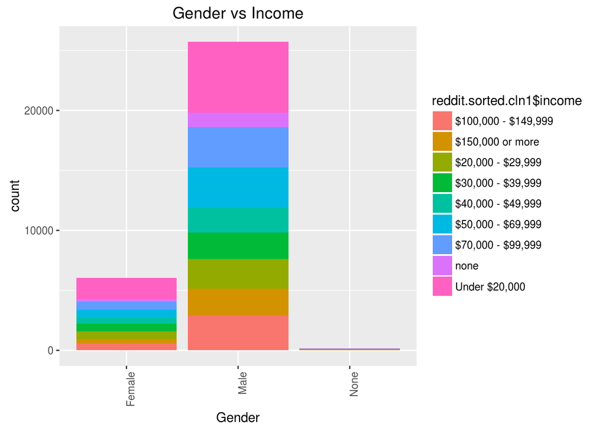

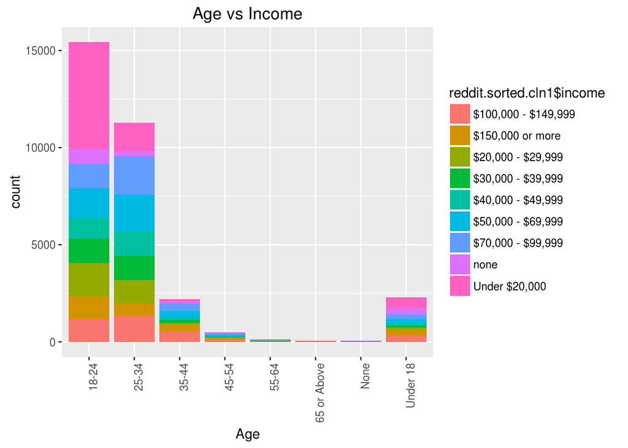

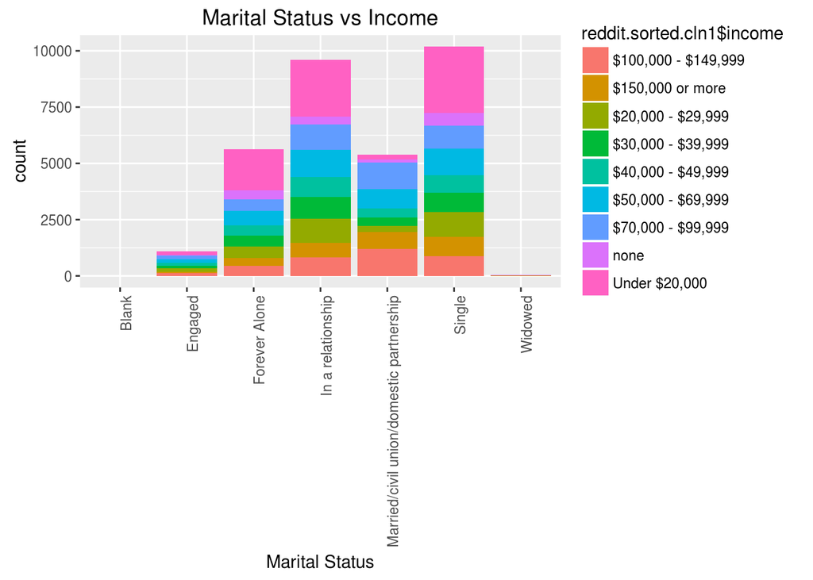

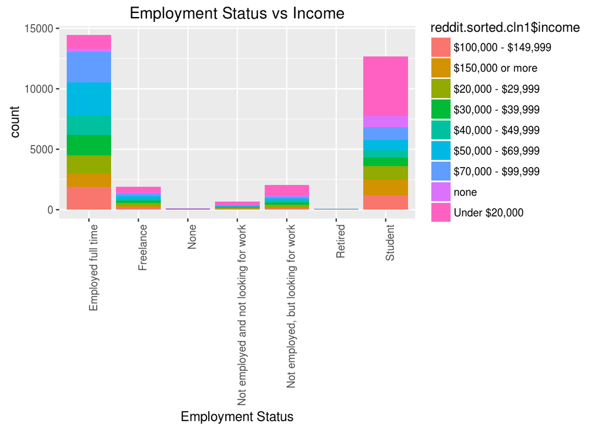

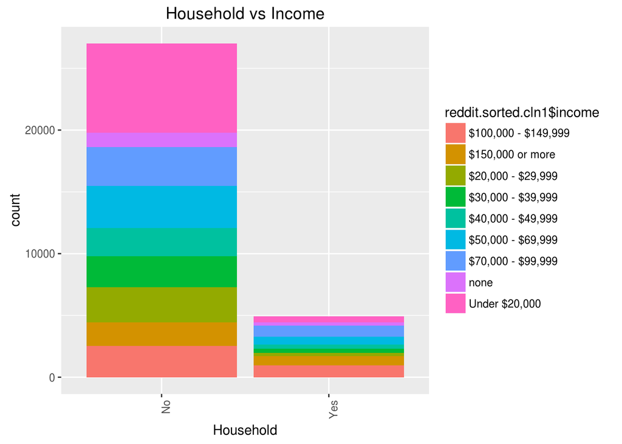

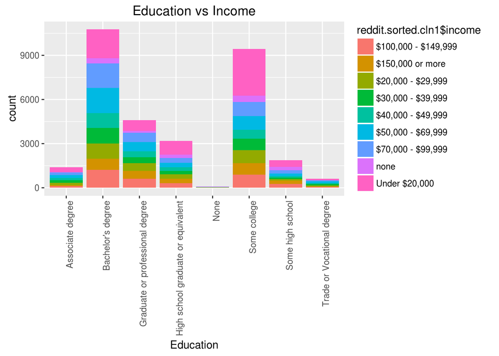

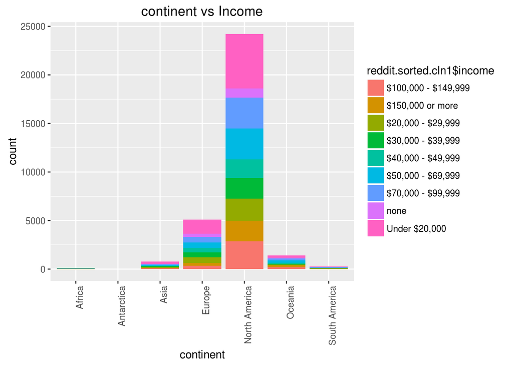

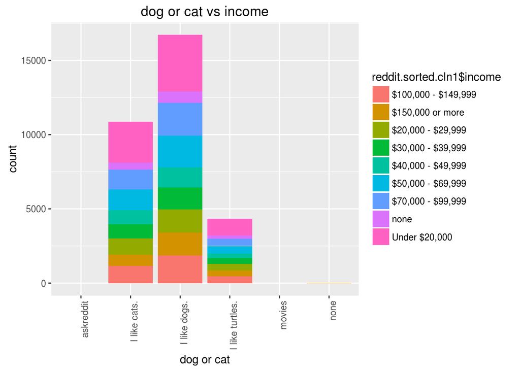

4. Correlation matrix: Correlation matrix is only valid for numeric data. However, the package ‘polycor’ has a function that estimates numeric values for categorical variables and generates a correlation matrix. It is called ‘polychoric’ matrix. Also, country needs to be converted back to a factor. Visiualizing the matrix shows that there is not really a good correlation between any of the variables.

```r
#correlation matrix
reddit.sorted.cln1$country <- as.factor(reddit.sorted.cln1$country)
library(polycor)
polycor <- hetcor(reddit.sorted.cln1)
```

[output not shown]

[output cut: 68 more lines]

[output not shown]

```r
polycor$correlations
```

```
##                gender          age     marital    employed    military
## gender     1.00000000  0.073995254  0.01129000 -0.11307104  0.25044012
## age        0.07399525  1.000000000 -0.01338121 -0.27765533  0.12056866
## marital    0.01129000 -0.013381207  1.00000000  0.03790214 -0.01501927
## employed  -0.11307104 -0.277655330  0.03790214  1.00000000 -0.14135168
## military   0.25044012  0.120568655 -0.01501927 -0.14135168  1.00000000
## household  0.05483415  0.422769285  0.06064946 -0.07760080  0.10840450
## education  0.01356478  0.101129700  0.00831294  0.32964223 -0.01814343
## country   -0.11784469  0.001323415  0.05350693 -0.01878122 -0.06820160
## income    -0.05983076 -0.207668659 -0.02652370  0.28087678 -0.05075126
## dogcat     0.10898302  0.003468512  0.01729604  0.01865428  0.02887832
## continent -0.11384408 -0.018898044  0.04574110 -0.03068077 -0.20140988
##             household    education      country      income       dogcat
## gender     0.05483415  0.013564785 -0.117844694 -0.05983076  0.108983025
## age        0.42276928  0.101129700  0.001323415 -0.20766866  0.003468512
## marital    0.06064946  0.008312940  0.053506926 -0.02652370  0.017296038
## employed  -0.07760080  0.329642233 -0.018781217  0.28087678  0.018654277
## military   0.10840450 -0.018143432 -0.068201596 -0.05075126  0.028878323
## household  1.00000000  0.127786476  0.025205088 -0.22751414  0.042011982
## education  0.12778648  1.000000000 -0.051287311  0.06577557  0.005825625
## country    0.02520509 -0.051287311  1.000000000 -0.03485265  0.001773717
## income    -0.22751414  0.065775569 -0.034852653  1.00000000 -0.014946758
## dogcat     0.04201198  0.005825625  0.001773717 -0.01494676  1.000000000
## continent  0.03762975  0.018443239  0.093968292 -0.08018401  0.010243634
##             continent
## gender    -0.11384408
## age       -0.01889804
## marital    0.04574110
## employed  -0.03068077
## military  -0.20140988
## household  0.03762975
## education  0.01844324
## country    0.09396829
## income    -0.08018401
## dogcat     0.01024363
## continent  1.00000000
```

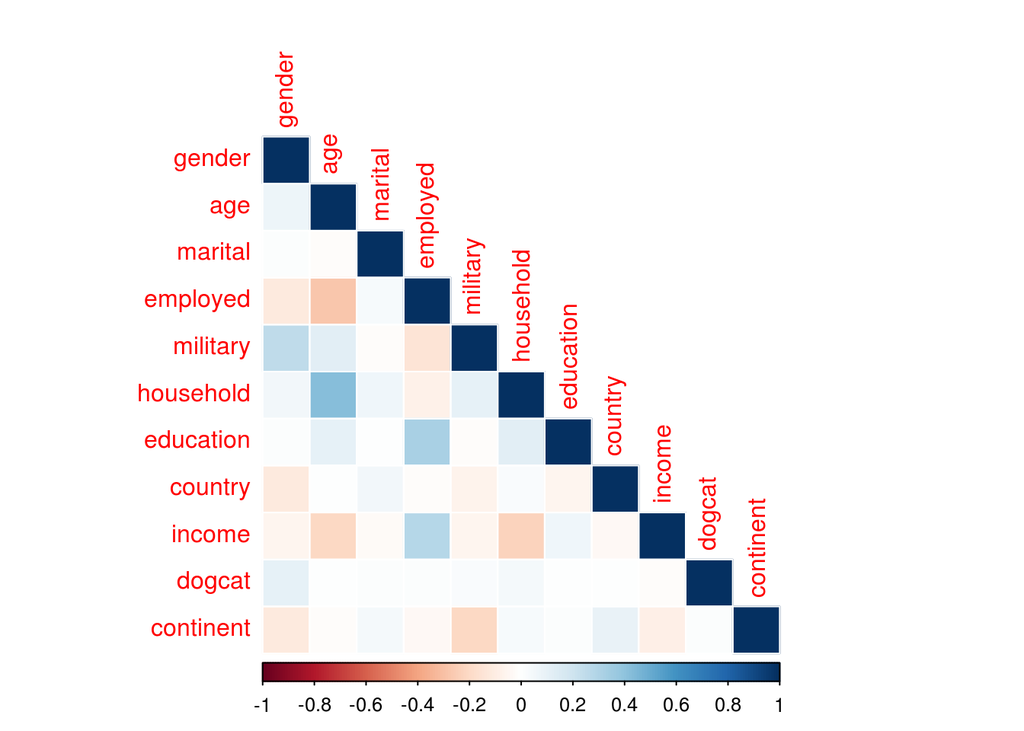

5. We are finally ready for a random forest model.
1. Separate train and test data using random sampling
2. Remove country from both dataset
3. Save the dependent variable and remove it
4. And finally generate the model. This was a bit of iterative process trying the model with various parameters

```r
#we are ready for random forest
index <- sample(nrow(reddit.sorted.cln1),nrow(reddit.sorted.cln1)/3)
reddit.test <- reddit.sorted.cln1[index, -which(names(reddit.sorted.cln1) %in% c("country"))]
reddit.train <- reddit.sorted.cln1[-index,-which(names(reddit.sorted.cln1) %in% c("country"))]
reddit.test.label <- reddit.test[,which(names(reddit.test) %in% c("income"))]
reddit.train.label <- reddit.train[,which(names(reddit.train) %in% c("income"))]
#remove dependent variabe
reddit.train.tmp <- reddit.train[,-which(names(reddit.train) %in% c("income"))]
reddit.test.tmp <- reddit.test[,-which(names(reddit.test) %in% c("income"))]
#build model
library(randomForest)
model <- randomForest(reddit.train$income~.,data = reddit.train.tmp,importance=TRUE,ntree=2000,sampsize=nrow(reddit.train.tmp),replace=TRUE)
model
```

```
##
## Call:
##  randomForest(formula = reddit.train$income ~ ., data = reddit.train.tmp,      importance = TRUE, ntree = 2000, sampsize = nrow(reddit.train.tmp),      replace = TRUE)
##                Type of random forest: classification
##                      Number of trees: 2000
## No. of variables tried at each split: 3
##
##         OOB estimate of  error rate: 68.42%
## Confusion matrix:
##                     $100,000 - $149,999 $150,000 or more $20,000 - $29,999
## $100,000 - $149,999                 422              174                48
## $150,000 or more                    303              179                30
## $20,000 - $29,999                    42               26               152
## $30,000 - $39,999                    62               41               128
## $40,000 - $49,999                    98               34                98
## $50,000 - $69,999                   183               89               143
## $70,000 - $99,999                   329               97                78
## none                                 58               44                18
## Under $20,000                        79               70               202
##                     $30,000 - $39,999 $40,000 - $49,999 $50,000 - $69,999
## $100,000 - $149,999                50                36               365
## $150,000 or more                   32                26               179
## $20,000 - $29,999                 111                59               395
## $30,000 - $39,999                 165                71               499
## $40,000 - $49,999                 105                47               531
## $50,000 - $69,999                 155                72               902
## $70,000 - $99,999                 109                62               632
## none                               17                18                62
## Under $20,000                      92                44               218
##                     $70,000 - $99,999 none Under $20,000 class.error
## $100,000 - $149,999               431   24           816   0.8216399
## $150,000 or more                  205   23           802   0.8993817
## $20,000 - $29,999                 150   17          1115   0.9264635
## $30,000 - $39,999                 215   10           698   0.9126522
## $40,000 - $49,999                 225   10           588   0.9729263
## $50,000 - $69,999                 430   27           722   0.6687477
## $70,000 - $99,999                 564   21           770   0.7881292
## none                               49   39           651   0.9592050
## Under $20,000                      99   55          4255   0.1679703
```

From the confusion matrix, we see our model is not doing very well. It has quite a high error rate. I was not able to calculate AUC score because this is a multi-class dependent variable. Maybe there is a way to do so, but have not figured it out as of this writing.